# Evaluation of 20 enset (*Ensete ventricosum*) landraces for response to *Xanthomonas vasicola* pv. *musacearum* infection

# 1. General information

This supplementary information mainly describes data analysis part used in this manuscript. The script used has been modified from [Schandry (2017)](https://www.frontiersin.org/articles/10.3389/fpls.2017.00623/full).

A common garden experiment was conducted at a single site on 20 enset (*Ensete ventricosum*) landraces of 14 months old seedlings to assess their resistance / tolerance against Xanthomonas wilt disease caused by *Xanthomonas vasicola pv. musacearum* (Xvm). Disease infection data was recorded as count of symptomatic and total leaves per plant for each landrace. Data recorded at 15 days interval starting from 21st days post inoculation (dpi) to 155th day for 10 time points. Percentage of symptomatic leaves calculated and converted into disease index of 0-4 range numeric score multiplying each record by 4 and named as ‘disease index’ or DI.

# 2. Installing packages required for data managment and analysis

If the required list of packages any are not available in the machine, then the missing package(s) will be installed from CRAN.

```r
# List of package required
packages = c("tidyr", "broom", "tibble", "dplyr", "ggplot2", "lme4", "lmerTest", "multcomp", "lsmeans", "MESS", 'agricolae', 'magrittr', "rms","coxme", "survival", "stringr","grid","tinytex")

# Install packages missing packages.
installed_packages <- packages %in% rownames(installed.packages())
if (any(installed_packages == FALSE)) {
  install.packages(packages[!installed_packages])
}
```

# 3. Data entry and specifying contrasts varaibles

## 3.1 Importing and formatting

The input data was named as enset_xvm.csv and need to be placed in the working directory so the the script will be able to read it.

```r
# get path to the current working direcotry
work_dir <- getwd()

path_to_enset_xvm <- file.path(work_dir, basename("enset_xvm.csv"))

enset_xvm<- read.csv(path_to_enset_xvm)
head(enset_xvm) # view the first six row of imported data
```

```
##   landrace plant ptno block ind dss21 leaf21 di21 dss35 leaf35 di35 dss50
## 1    Lemat Enset    1     1   1     0      6    0     0      5    0     0
## 2    Lemat Enset    2     1   1     0      5    0     0      4    0     0
## 3    Lemat Enset    3     1   1     0      7    0     0      6    0     0
## 4    Lemat Enset    4     1   1     0      7    0     0      7    0     0
## 5    Lemat Enset    5     1   1     0      7    0     0      7    0     0
## 6    Lemat Enset    6     1   1     0      6    0     0      6    0     0
##   leaf50 di50 dss65 leaf65 di65 dss80 leaf80 di80 dss95 leaf95 di95 dss110
## 1      6    0     1      6 0.67     2      6 1.33     2      7 1.14      2
## 2      5    0     0      5 0.00     0      5 0.00     0      6 0.00      0
## 3      7    0     1      6 0.67     1      6 0.67     1      7 0.57      2
## 4      7    0     0      7 0.00     1      7 0.57     1      8 0.50      2
## 5      7    0     0      7 0.00     0      7 0.00     0      7 0.00      0
## 6      6    0     0      6 0.00     0      6 0.00     0      6 0.00      0
##   leaf110 di110 dss125 leaf125 di125 dss140 leaf140 di140 dss155 leaf155 di155
## 1       6  1.33      2       7  1.14      1       5  0.80      1       4   1.0
## 2       7  0.00      1       6  0.67      0       5  0.00      0       4   0.0
## 3       6  1.33      2       6  1.33      2       6  1.33      2       5   1.6
## 4       6  1.33      2       8  1.00      1       7  0.57      0       7   0.0
## 5       5  0.00      1       6  0.67      1       5  0.80      1       4   1.0
## 6       6  0.00      0       6  0.00      0       7  0.00      0       7   0.0
```

In the dataframe variable dss, leaf and di refers to count of diseased leaves, count of total leaves, and disease index, respectively. The numbers trailing dss, leaf, and di variables indicate the day on which data was recorded. Disease index is calculated as 4 times percentage of diseased leaves (4*dss/leaf). For details see Material and Method section of the manuscript.

Inspect data structure

```
## 'data.frame':    600 obs. of  35 variables:
##  $ landrace: chr  "Lemat" "Lemat" "Lemat" "Lemat" ...
##  $ plant   : chr  "Enset" "Enset" "Enset" "Enset" ...
##  $ ptno    : int  1 2 3 4 5 6 7 8 9 10 ...
##  $ block   : int  1 1 1 1 1 1 1 1 1 1 ...
##  $ ind     : int  1 1 1 1 1 1 1 1 1 1 ...
##  $ dss21   : int  0 0 0 0 0 0 0 0 0 0 ...
##  $ leaf21  : int  6 5 7 7 7 6 7 6 5 5 ...
##  $ di21    : num  0 0 0 0 0 0 0 0 0 0 ...
##  $ dss35   : int  0 0 0 0 0 0 0 0 0 0 ...
##  $ leaf35  : int  5 4 6 7 7 6 7 6 5 5 ...
##  $ di35    : num  0 0 0 0 0 0 0 0 0 0 ...
##  $ dss50   : int  0 0 0 0 0 0 0 0 0 0 ...
##  $ leaf50  : int  6 5 7 7 7 6 7 6 5 5 ...
##  $ di50    : num  0 0 0 0 0 0 0 0 0 0 ...
```

[output cut: 21 more lines]

The wide formatted enset_xvm was converted to long format for ease of analysis. In order to keep the original data as it was we have grouped identical variable together for all landraces and then regrouped into single dataframe to convert it to long formatted data.

```r
#extract  number of leaves showing disease symptoms at each evaluation day
leaf_dss=enset_xvm[,c(1:6,9,12,15,18,21,24,27,30,33)]

#extract  total leaves at each evaluation day
leaf_num <- enset_xvm[,c(1:5,7,10,13,16,19,22,25,28,31,34)]

#extract  disease index values at each evaluation day
di_wk <- enset_xvm[,c(1:5,8,11,14,17,20,23,26,29,32,35)]

library(tidyr)
#convert the extracted data into long format
leaf_dss_long <- gather(leaf_dss,key = "dpi",
                     value = "dss_leaf",
                     dss21:dss155,na.rm = F)# converting data of disease leaf (this is 3 to 13) into long format
leaf_num_long <- gather(leaf_num,key = "leaf_number",
                     value = "leaf_num",
                     leaf21:leaf155,na.rm = F)#converting total leaf data (this is 3 to 13) into long format
di_wk_long <- gather(di_wk,key = "di",
                  value = "disease_index",
                  di21:di155,na.rm = F)# converting data disease index (this is 3 to 13) into long format

#Combine long formatted subset data
enset_xvm_long <- cbind(leaf_dss_long,leaf_num_long$leaf_num,di_wk_long$disease_index)

enset_xvm_long$subject <- c(1:nrow(enset_xvm_long))# add subject variable. This variable helps to assign a unique, numeric identifier to each individual.
enset_xvm_long$count_dslf <- c(rep(1,6000))# add variable count_dslf: a repeats of 1 from 1 to the length of data set (6000). This variable will be used to count the number of observations in landrace at each evaluation period that show disease. It might be used to calculate incubation period of landraces for the disease under study.
colnames(enset_xvm_long) <- c("landrace", "plant", "ptno", "block", "ind", "dpi", "diseased", "leaf", "di", "subject", "count_dslf")# rename column headings
enset_xvm_long$id <- interaction(enset_xvm_long$landrace,enset_xvm_long$ptno,enset_xvm_long$block,enset_xvm_long$ind) # create id column of landrace, plant number and block.

enset_xvm_long <- na.omit(enset_xvm_long) #Generate a table that does not contain missing observations
enset_xvm_long$dpi <- na.omit(as.numeric (unlist( strsplit( as.character( enset_xvm_long$dpi ), "dss" ))))  #discard the "X" and save the number as a number (instead of a factor).

# Factorize variables landrace, plant and block
enset_xvm_long$block <- as.factor(enset_xvm_long$block)
enset_xvm_long$plant <- as.factor(enset_xvm_long$plant)
enset_xvm_long$landrace <- as.factor(enset_xvm_long$landrace)

# # view structure of long formatted data
# str(enset_xvm_long)
```

Checking overall summary for missing values, or out of range misrecorded values. Missing values coded as NA and will be observed print in summary function if there are any. Out of range values can be checked by looking at the min and max values of the summary table and make sure if they’re within the expected range.

```r
summary(enset_xvm_long)
```

```
##         landrace      plant           ptno      block         ind
##  Abatemerza : 300   Enset:6000   Min.   : 1.0   1:2000   Min.   : 1.00
##  Ado        : 300                1st Qu.: 3.0   2:2000   1st Qu.: 5.75
##  Alagena    : 300                Median : 5.5   3:2000   Median :10.50
##  Arkiya     : 300                Mean   : 5.5            Mean   :10.50
##  Bededet    : 300                3rd Qu.: 8.0            3rd Qu.:15.25
##  Bota Arkiya: 300                Max.   :10.0            Max.   :20.00
##  (Other)    :4200
##       dpi           diseased           leaf              di
##  Min.   : 21.0   Min.   : 0.000   Min.   : 1.000   Min.   :0.000
##  1st Qu.: 50.0   1st Qu.: 0.000   1st Qu.: 5.000   1st Qu.:0.000
##  Median : 87.5   Median : 2.000   Median : 6.000   Median :1.330
##  Mean   : 87.6   Mean   : 2.287   Mean   : 6.255   Mean   :1.483
##  3rd Qu.:125.0   3rd Qu.: 4.000   3rd Qu.: 7.000   3rd Qu.:2.400
##  Max.   :155.0   Max.   :15.000   Max.   :20.000   Max.   :4.000
##
##     subject       count_dslf           id
##  Min.   :   1   Min.   :1    Lemat.1.1.1:  10
##  1st Qu.:1501   1st Qu.:1    Lemat.2.1.1:  10
##  Median :3000   Median :1    Lemat.3.1.1:  10
##  Mean   :3000   Mean   :1    Lemat.4.1.1:  10
##  3rd Qu.:4500   3rd Qu.:1    Lemat.5.1.1:  10
##  Max.   :6000   Max.   :1    Lemat.6.1.1:  10
##                              (Other)    :5940
```

## 3.2 Defining the contrasts

Assigning and setting proper contrast is in analysis of variance. See for detail [here](https://cran.r-project.org/web/packages/codingMatrices/vignettes/codingMatrices.pdf). “Treatment” contrasts specify that the first alphabetical level will be used as a reference for all others (see landrace below), while a “sum” constrast means that the reference value is the mean across all levels of that variable (the grand mean).

```r
####Specify what should be "appropriate" contrasts
contrasts(enset_xvm_long$landrace) <- "contr.treatment" #First alphabetical landrace will be the baseline!
contrasts(enset_xvm_long$block) <- "contr.sum" # blockes will be averaged to generate the baseline!
```

## 3.3 Add a censoring variable

A new variable called “Useful” is added the data and is a binary yes/no variable. The purpose of this variable is marking observations, that are re-observations of a subject that has previously reached disease index 4. As disease index of 4 means 100% wilting, the plant either dead or considered as dead when it reached this degree of wilting. Since death is permanent, continuing to observe this plant is unlikely to provide new information. To more accurately capture the linear phase of disease development, all observations where no symptoms are visible, except the one on the day before disease onset, will also be assigned to Useful = No.

```r
###Interesting R-related observation, the below does not work when subsetting is done with filter(),
###because filter does not retain rownames!
for (i in 1:max(enset_xvm_long$subject)) { ###Go by subject
  dummy1 <- enset_xvm_long[enset_xvm_long$subject==i,] ##Create a first dummy object, that is a subset of the full data containing the current subject
  if(min(dummy1$di) == 0){
  #remove those observations that are before disease onset, except the one directly before disease onset.
  dummy1 <- dummy1[dummy1$dpi %in% (max(dummy1$dpi[dummy1$di==0]):max(dummy1$dpi)),]
  }
  if (max(dummy1$di) == 4) { ###If this subject dies at some point
    dummy2 <- dummy1[dummy1$di==4,] ###Make a new dummy object, that only contains those recordings where di=4
    NEW <- enset_xvm_long[enset_xvm_long$subject==i & (enset_xvm_long$dpi %in% min(dummy1$dpi):min(dummy2$dpi)),] ###Generate data subset "NEW", which contains those observations for a subject, that are between (including) the last recording where di=0 and the first recording where disease index is 4.
  } else { ###If this dubject does not die
    NEW <- dummy1 ###New is the same as dummy1
  }
  enset_xvm_long$Useful[rownames(enset_xvm_long) %in% rownames(NEW)] <- c("Yes") ###All of those row(names) that are part of the "NEW" object are useful. Therefore these receive status "Yes" in column "Useful"
}
enset_xvm_long$Useful[which(is.na(enset_xvm_long$Useful))] <- c("No") ###Those that are not yes (and therefore are NA) become No
rm(dummy1,dummy2)
```

Inspecting the final data before analysis

```r
library(broom)
library(tibble)
as_tibble(enset_xvm_long)
```

```
## # A tibble: 6,000 × 13
##    landrace plant  ptno block   ind   dpi diseased  leaf    di subject
##    <fct>    <fct> <int> <fct> <int> <dbl>    <int> <int> <dbl>   <int>
##  1 Lemat    Enset     1 1         1    21        0     6     0       1
##  2 Lemat    Enset     2 1         1    21        0     5     0       2
##  3 Lemat    Enset     3 1         1    21        0     7     0       3
##  4 Lemat    Enset     4 1         1    21        0     7     0       4
##  5 Lemat    Enset     5 1         1    21        0     7     0       5
##  6 Lemat    Enset     6 1         1    21        0     6     0       6
##  7 Lemat    Enset     7 1         1    21        0     7     0       7
##  8 Lemat    Enset     8 1         1    21        0     6     0       8
##  9 Lemat    Enset     9 1         1    21        0     5     0       9
## 10 Lemat    Enset    10 1         1    21        0     5     0      10
## # ℹ 5,990 more rows
## # ℹ 3 more variables: count_dslf <dbl>, id <fct>, Useful <chr>
```

```r
# tidy(enset_xvm_long) ###This can be used to assess the descriptive statistics of the data.
```

# 4. Analysis of the area under the disease progression curve (AUDPS)

Here the data is summarized to visualize area under the curve using disease index (y) and time (x).

Summarizing disease index recordings and generating disease area plot

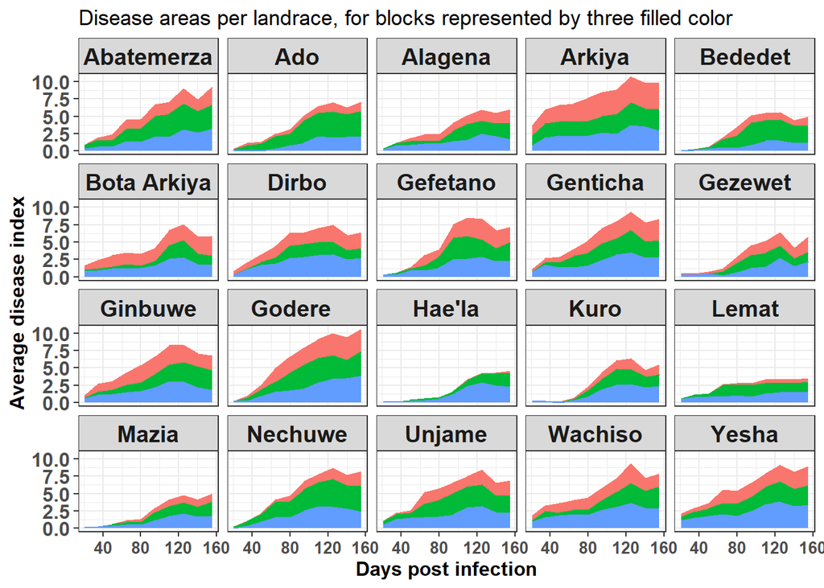

```r
library(dplyr)
di_summary <- enset_xvm_long %>%
  group_by(plant, landrace, block, dpi) %>%
  summarise(mean=mean(di),sd=sd(di),se=sd(di)/sqrt(length(di))) ##calculate within block mean, sd, and se for each plant/landrace combination.
##Averages within each replicate. This summary table is mainly helpful for plotting, not used for analysis...
colnames(di_summary) <- c("plant", "landrace", "block", "dpi", "mean", "sd", "se") ### rename column names

library(ggplot2)
ggplot(di_summary,aes(x=dpi,y=mean)) + ###Use data di_summary
  geom_area(aes(color=block,fill=block))+
  # geom_line() +#show line by each block
  #aes(x=dpi,y=mean,color=landrace) + ###Color by landrace, specify x and y.
  # geom_area(aes(fill=block),position="identity",alpha=0.15) + ###Area plot, colored by landrace
  facet_wrap(~landrace) + ###One plot per landrace
  labs(x = "Days post infection", y = "Average disease index") + #Labels
  ggtitle("Disease areas per landrace, for blocks represented by three filled color")+ #Title
  theme_bw()+
  theme(strip.text.x = element_text(size = 14,face="bold"),
        axis.text.x = element_text(size = 10,face = "bold"),
        axis.title.x = element_text(size = 12,face = "bold"),
        axis.title.y = element_text(size = 12,face = "bold"),
        axis.text.y =element_text(size = 12,face ="bold" ),
        legend.position = "none")
```

From this plot, one can see that in the example dataset the areas differ quite drastically among different landraces. To calculated the actual audps for each individual in the dataset a new data frame is created. AUDCP is calculated using audps function in agricolae package.

```r
library("MESS")
library('agricolae') # Used to calculated audps
library('magrittr')  # Adds %>% operator for chaining commands

# Calculate AUDPS
audps_data <- enset_xvm_long %>%
  group_by(landrace, ptno, block) %>% # do any following calculations on every combination of treatments
  summarise(audps = round(audps(di, dpi),0))
```

## 4.1 Model

Linear model and linear mixed effects model were fitted to identify and select the better fit model to area under disease progress data to be used for final analysis.

```r
library("lme4")
library("lmerTest")
auc_lm <- lm(audps~landrace+block,data=audps_data) #Linear model to identify landrace and block effect.
auc_lm1<-lm(audps~landrace,data=audps_data) ### linear model to identify landrace effects.
auc_lmer <- lmer(audps ~ landrace + (1|block),data = audps_data  ) #Linear mixed effects model. AUC modeled as a function of landrace and random effects of block.
AIC(auc_lm,auc_lm1,auc_lmer) #Lower AIC, better fit, linear mixed model is slightly better. #Hence, mixed model with block as random effect will be used for further analysis.
```

```
##          df      AIC
## auc_lm   23 7164.997
## auc_lm1  21 7194.536
## auc_lmer 22 7021.008
```

Summary of mixed linear model fit to AUDPS

```r
summary(auc_lmer)  ### A model summary, containing information on the model.
```

```
## Linear mixed model fit by REML. t-tests use Satterthwaite's method [
## lmerModLmerTest]
## Formula: audps ~ landrace + (1 | block)
##    Data: audps_data
##
## REML criterion at convergence: 6977
##
## Scaled residuals:
##     Min      1Q  Median      3Q     Max
## -3.3257 -0.6504 -0.0080  0.6636  3.6631
##
## Random effects:
##  Groups   Name        Variance Std.Dev.
##  block    (Intercept)  674.8   25.98
##  Residual             8642.7   92.97
## Number of obs: 600, groups:  block, 3
##
## Fixed effects:
##                     Estimate Std. Error       df t value Pr(>|t|)
## (Intercept)          264.567     22.650    9.148  11.681 8.39e-07 ***
## landraceAdo          -66.867     24.004  578.000  -2.786  0.00552 **
## landraceAlagena      -94.400     24.004  578.000  -3.933 9.42e-05 ***
## landraceArkiya       121.967     24.004  578.000   5.081 5.07e-07 ***
## landraceBededet     -107.900     24.004  578.000  -4.495 8.40e-06 ***
## landraceBota Arkiya  -48.667     24.004  578.000  -2.027  0.04307 *
## landraceDirbo        -19.133     24.004  578.000  -0.797  0.42572
## landraceGefetano     -30.800     24.004  578.000  -1.283  0.19996
## landraceGenticha      12.167     24.004  578.000   0.507  0.61244
## landraceGezewet     -109.067     24.004  578.000  -4.544 6.73e-06 ***
## landraceGinbuwe       -2.033     24.004  578.000  -0.085  0.93252
## landraceGodere        43.067     24.004  578.000   1.794  0.07331 .
## landraceHae'la      -167.633     24.004  578.000  -6.984 7.93e-12 ***
## landraceKuro        -115.200     24.004  578.000  -4.799 2.03e-06 ***
## landraceLemat       -144.067     24.004  578.000  -6.002 3.45e-09 ***
## landraceMazia       -145.200     24.004  578.000  -6.049 2.62e-09 ***
## landraceNechuwe      -11.200     24.004  578.000  -0.467  0.64097
## landraceUnjame        -5.300     24.004  578.000  -0.221  0.82533
## landraceWachiso        4.833     24.004  578.000   0.201  0.84049
## landraceYesha         32.200     24.004  578.000   1.341  0.18030
## ---
## Signif. codes:  0 '***' 0.001 '**' 0.01 '*' 0.05 '.' 0.1 ' ' 1
```

Model summaries contain information on the estimated mean (Estimate) and standard errors, together with a t - and corresponding p-value in the output of the summary function. Note, that the above only contains information on differences between different levels and the reference, which is called (Intercept) in this case it’s landrace Abatemerza. The reference is contrast dependent.

```r
ranova(auc_lmer)
```

```
## ANOVA-like table for random-effects: Single term deletions
##
## Model:
## audps ~ landrace + (1 | block)
##             npar  logLik    AIC    LRT Df Pr(>Chisq)
## <none>        22 -3488.5 7021.0
## (1 | block)   21 -3500.9 7043.8 24.798  1  6.368e-07 ***
## ---
## Signif. codes:  0 '***' 0.001 '**' 0.01 '*' 0.05 '.' 0.1 ' ' 1
```

```r
#The result displays block has a significant random effect explaining the importance of including block variable in the model.
```

## 4.2 Post-hoc of audps

```r
library("multcomp")
library("lsmeans")
##carry out mean separation and adjust for compact letter desply (cld)###
cld_audps_lmer <- cld(glht(auc_lmer, linfct = mcp(landrace = "Tukey")), test = adjusted("holm"))###Save letters
cld_audps_cbind <- cbind(levels(enset_xvm_long$landrace),cld_audps_lmer$mcletters$Letters) ###bind letters to columns of respective landraces
cld_audps_df <- data.frame(cld_audps_cbind)#format extracted cld with landraces from mean separation to data.frame
colnames(cld_audps_df) <- c("landrace","aud_let")###Name columns
rownames(cld_audps_df) <- NULL #remove repeated rownames
cld_audps_df$landrace <- as.factor(cld_audps_df$landrace)

#Extrating estimated mean and confidence interval of landraces using lsmeanLT
audps_lsmeansLT <- lsmeansLT(auc_lmer,test.effs="landrace")#lsmeansLT calculates Least Squares Means and Confidence Intervals for the factors of a fixed part of mixed effects model of lmer object
#audps_lsmeansLT=audps_lsmeansLT$lsmeans.table# extract table containing means with confidence interval
rownames(audps_lsmeansLT) <- NULL #remove row names containing duplicates of landrace lists
audps_lsmeansLT<-as.data.frame(audps_lsmeansLT)[,-1]

library (dplyr)

cld_audps <- cbind(audps_lsmeansLT,cld_audps_df[,2]) #combine extracted mean data from lmer using lsmeansLT and dataframe of letters from cld
rownames(cld_audps) <- NULL #remove repeated rownames
colnames(cld_audps)=c("landrace", "audps", "Stand_Error","df","t-value", "lower", "upper", "p_value", "audp_let")# rename column of combined orinal data. Here landrace is duplicated and can be remove but left as landrace
cld_audps <- as.data.frame(cld_audps) #Coerce data containing means with confidence interval and letter display to dataframe
cld_audps <- cld_audps[order(cld_audps$audps),]# reorder by mean value to cheat ggplot
#cld_audps_lmerer$landrace<-factor(cld_audps_lmerer$landrace,levels=cld_audps_lmerer$landrace)# put factors in level

audps_data__cld <- left_join(audps_data,cld_audps_df, by ="landrace",copy=T) ###Add letter information to raw data - audps
head(audps_data__cld)
```

```
## # A tibble: 6 × 5
## # Groups:   landrace, ptno [2]
##   landrace    ptno block audps aud_let
##   <fct>      <int> <fct> <dbl> <chr>
## 1 Abatemerza     1 1       146 ab
## 2 Abatemerza     1 2       386 ab
## 3 Abatemerza     1 3       228 ab
## 4 Abatemerza     2 1       311 ab
## 5 Abatemerza     2 2       327 ab
## 6 Abatemerza     2 3       286 ab
```

## 4.3 Ploting audps

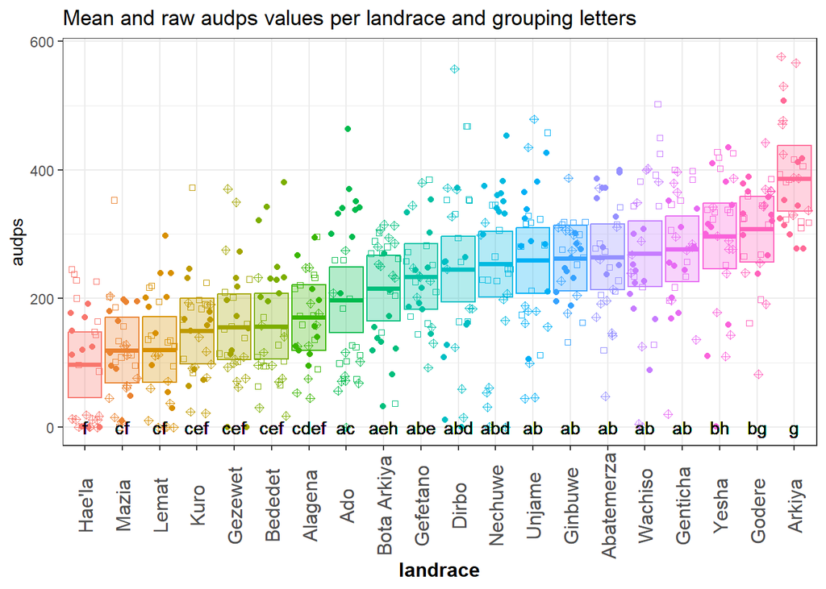

```r
####Generate plot of meanCI of AUDCP with significance letters and raw data as jittered points
cld_audps <- cld_audps[order(cld_audps$audps),]# reorder by mean value to cheat ggplot
cld_audps$landrace <- factor(cld_audps$landrace,levels = cld_audps$landrace)#put factors in level

ggplot(aes(x=landrace, y=audps, color=landrace),data=audps_data__cld) + ###Plot the audps_data
  scale_shape_manual(values=c(9, 19, 22,26))+
  geom_crossbar(data = cld_audps, aes(x = landrace, y = audps, ymin = lower, ymax = upper,fill=landrace), alpha=0.3) +
  geom_jitter(aes(shape=block),data = audps_data__cld) + ###with jitter overplotted, symbol shape defined by block
  geom_text(aes(x=landrace, y=0.039, label=aud_let),color="black", data=audps_data__cld) + ###Get the letters from auc_cld
  #and write those to position y=-3
  labs(y="audps") + #Y-Axis label
  ggtitle("Mean and raw audps values per landrace and grouping letters") +#Title
  theme_bw()+
  theme(axis.title.x = element_text(face="bold", size=12), axis.text.x  =  element_text(angle=90, vjust=0.5, size=12))+
  theme(legend.position="none")
```